# Homework 4

#### Matthew Jacobs

```python
import numpy as np
import matplotlib.pyplot as plt
from matplotlib.colors import LinearSegmentedColormap
import matplotlib.pyplot as plt
```

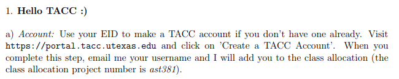

Done! Account name: mnjacobs

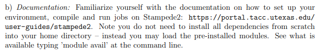

Done. With Erica's help learned how to navigate the different root folders and where to install things. Installed anaconda and got the correct environment setup.

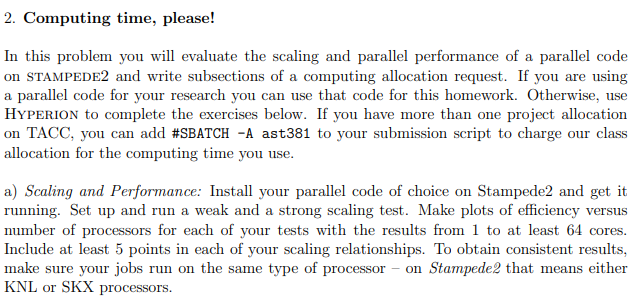

Hyperion proved to be quite difficult to even get installed. I had to use a 3.6 python environment. Running into an issue when trying to run the YSO python script to generate the rtin and rtout files needed for my slurm bash script. I'm getting the following error:

[output not shown]

I've been troubleshooting this for a while and tried many things. I've verified my python paths and environment. I've verified numpy install. Using a pre-generated rtin from a classmate, hyperion is now flagging errors for h5py. Verified that it is installed and up to date in this environment.

```
(comp) c455-071[knl](101)$ hyperion -m 32 hw_q3c.rtin hw_q3c.rtout
Traceback (most recent call last):
  File "/home1/08776/mnjacobs/anaconda3/envs/comp/bin/hyperion", line 40, in <module>
    import h5py
  File "/home1/08776/mnjacobs/anaconda3/lib/python3.8/site-packages/h5py/__init__.py", line 26, in <module>
    from . import _errors
ImportError: cannot import name '_errors'
```

Tried manually uninstalling and then reinstalling. It gives same error when just trying to import h5py directly in a python3 shell.

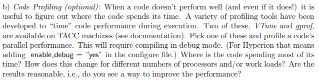

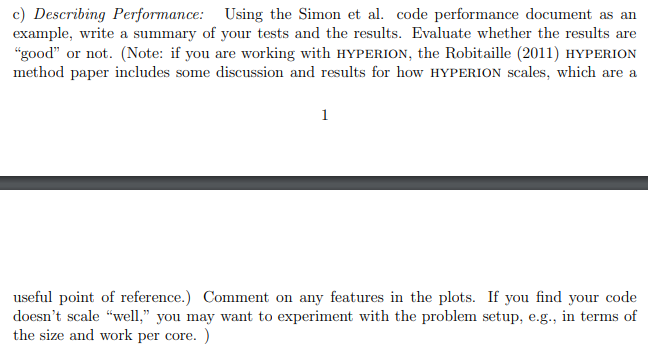

Was unable to get hyperion functional on TACC. Installed, but was just one error after another when trying to utilize it. Many hours invested and peers consulted.

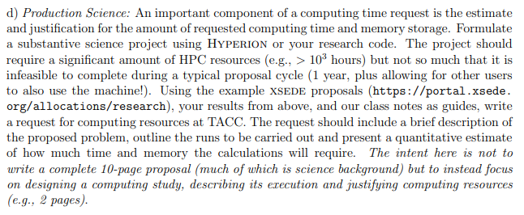

I have included the proposal in the Canvas submission, as well as my github repo for this class. One thing to note: Given how long my ex-colleague would spend running a single target on his laptop, I was shocked by how fast the entire catalogue would run on Stampede2 with 4096 cores. I think I made a mistake somewhere, likely in estimating his compute times. I took some liberties there, but we do expect a massive increase in efficiency when going from a laptop to TACC! This proposal would most certainly not be suited for TACC. I chose it because I assumed it would take quite a few compute hours, but by the time I realized the entire thing would only take 2 hours on that many cores, I was too deep into the proposal to start over! Consider it a learning experience.

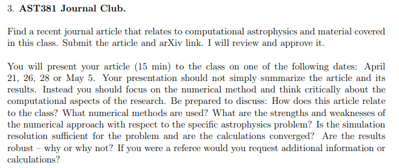

I have chosen https://ui.adsabs.harvard.edu/abs/2022MNRAS.512..884R/abstract which uses NBODY6+ to conduct N-body simulations on black holes in compact star clusters to study merger events.